# Civil Wars

PO 4700: Contemporary International Relations

## Patterns of Civil Wars

## Why Study Civil Wars?

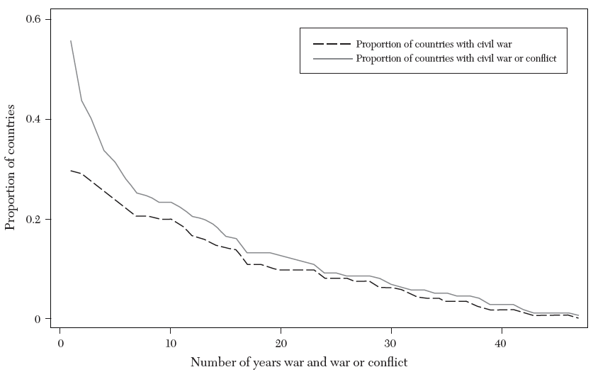

## Why Study Civil Wars?

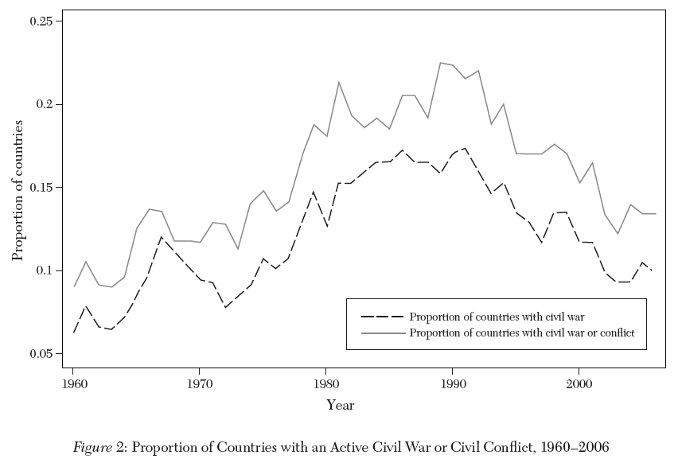

Source: blattman 2010

## Where?

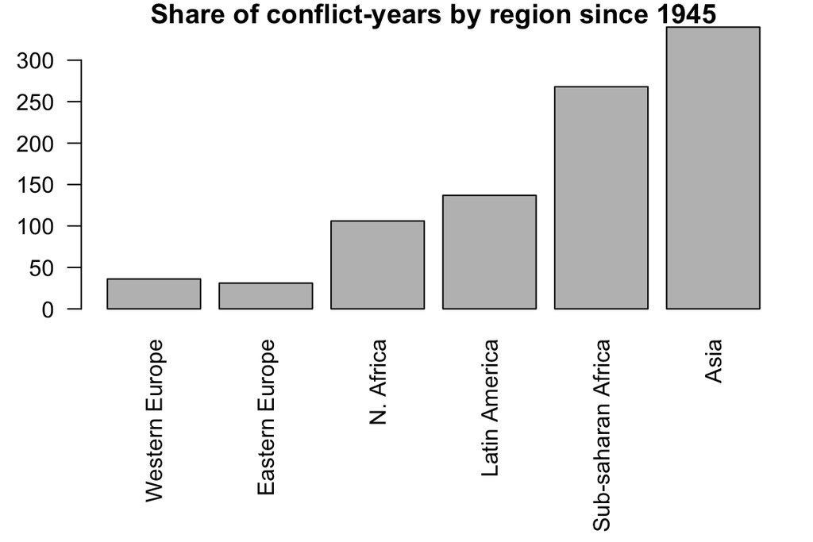

## Where?

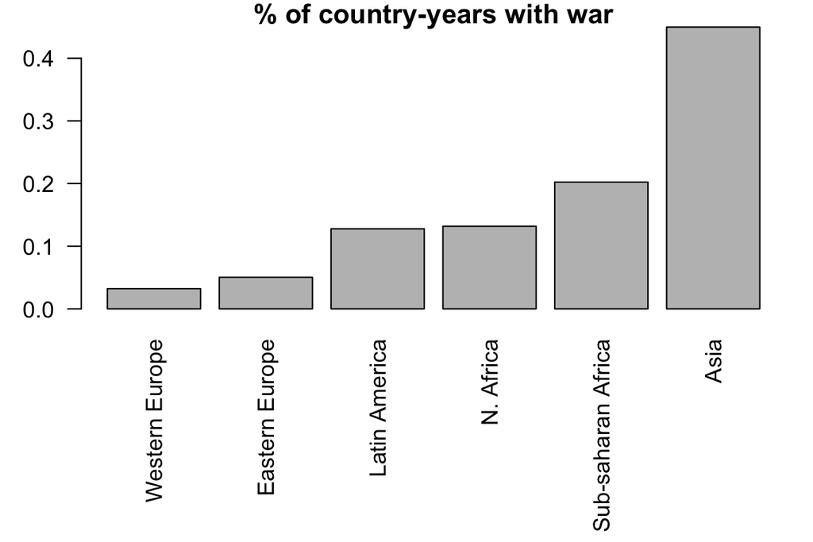

## What is a civil war?

- Armed conflict between organised actors within a state
- Mostly government vs rebel group(s)
  - 1,000 battle deaths
  - 25 battle deaths
- Government massacres excluded

## Causes of Civil Wars

### 1. Motivation (aka grievances)

## Sources of Grievances

### Gains and Losses

- Collective disadvantages (aka horizontal inequality)
- Loss of political autonomy
- Repression and Political exclusion

## Sources of Grievances

### Diversity?

- Ethnic and religious fractionalization: Counterintuitive effect
  - See also Chewas and Tumbukas article
- Vertical Inequality: No discernible effect

## Sources of Grievances

### Climate Change?

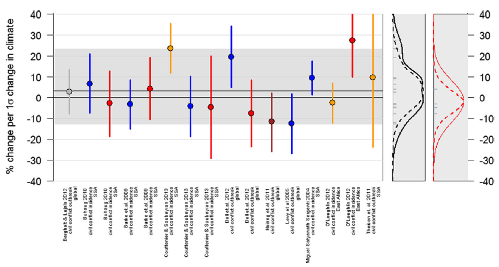

Source: "Buhaug et al, 'One effect to rule them all? A comment on climate and conflict', Climatic Change (2014) 127:391–397

## Causes of Civil Wars

### 2. Feasibility

## Greed vs. Grievances

- Grievances, aka motivation
- Greed, aka opportunity
  - Collier: "Grievance is to a rebel organization what image is to a business"

## Does Motivation really matter?

- Ethnic tensions \(\rightarrow\) civil war

OR

- Civil war \(\rightarrow\) ethnic tensions ?

## Greed

What matters is feasibility. Feasibility depends on:

- Whether you can get recruits \(\rightarrow\) opportunity costs
- Feasibility of fighting

## Opportunity costs

Factors that lead young men (mostly) to choose fighting over other activities \(\rightarrow\) facilitates recruitment

- Poverty
- Fast population growth
- Low economic growth / decline
  - Spurious?
- Education

\(\Rightarrow\) Typical profile: Young, uneducated male

## Opportunity costs

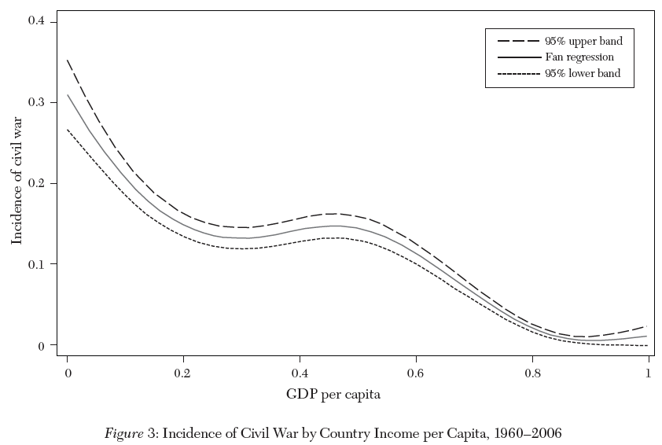

Source: Blattman 2010

## Feasibility

### Recruiting

- Problem of free-riding
- Solutions
  - Ideological beliefs
  - Trust from same ethnic or religious group
  - Forcible recruitment
  - Large population

## Feasibility

### State capability

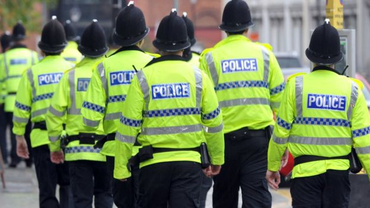

Source: BBC

## Feasibility

### Finance: Natural Resources

- Oil and Diamonds
  - Highly lootable
  - Provides financial resources to sustain war

## Feasibility

### Geography

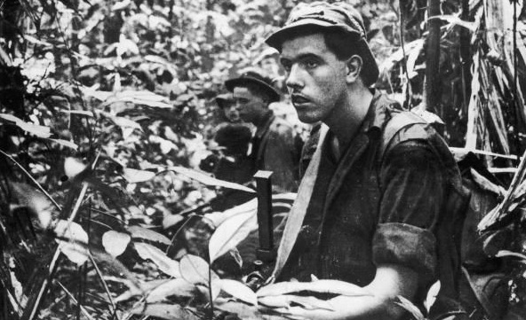

- Rugged terrain
  - jungle, mountains
- Infrastructures
- Population dispersion

## Feasibility

### Foreign Support

- Direct intervention
  - sending forces across the border
  - provide arms, money or training
- Operate from bases abroad, e.g. sanctuaries
- Why would foreign governments support them?
  - irredentist groups receive support from the state they want to join (e.g., Serbia and ethnic serbs)
  - ethnic kin in other states (diasporas) (e.g., Irish americans support northern Ireland)
- Ideology (e.g. Iran supports Hamas and Hezbollah)

## Feasibility

### Foreign Support

- Rebel movements more likely if supported by ethnic diasporas
- BUT difficulties:
  - Direction of causality
  - Long established diasporas vs. recent ones
  - Diasporas may support state, not rebels. May be unintentional, if unilateral transfers are taxed by state and revenye used to fund military expenditure

## Causes of Civil Wars

### 3. Bargaining Failures

## 3 Puzzles left

Motivation and feasibility still cannot explain:

- Variation in outbreak of violence across countries
- Variation in duration of conflicts
- Variation in recurrence of conflicts

## The Problem with Civil War

- Bargaining is harder than in interstate wars:
  - Fewer negotiated settlements are signed
  - If signed, less likely to be implemented
  - If implemented, more likely to break down
- Civil wars tend to
  - Last longer
  - End more often in decisive military victory
  - Recur more often

## Explaining variation in Civil War *Onset*

### Information Asymmetries

- Particularly severe in intra-state conflicts
  - Government about rebels
  - Rebels about themselves
- Does not explain everything: learning should occur

## Explaining variation in Civil War *Onset*

### Commitment Problems

- Problem of Enforcement
- Commitment problems particularly acute in civil wars
  - Large power asymmetry
  - Settlement shifts the balance of power

## Explaining variation in Civil War *Duration*

- Wars may last longer because of:
  - Strong motivation
  - Evenly matched combatants
  - Profitability
- Still does not answer why deals cannot be struck
  - Pay the price
  - Split in 1/2
  - Soldiers can be compensated

## Explaining variation in Civil War *Duration*

### Information Problems

- How much and how fast info is revealed affects duration
- Info is not revealed at the same rate in every conflict
  - Guerilla wars / terrorist tactics: start and stop, remote
- Multiple, shifting factions, and/or outside actors

## Explaining variation in Civil War *Duration*

### Commitment Problems

- Two main sources of commitment problems:
  - Treaties are typically signed during periods of government weakness
  - Demobilization period
- Two types of countries less likely to overcome these problems
  - Clear asymmetry of power
  - No chance of 3rd party intervention.

## Explaining variation in Civil War *Recurrence*

### Information Problems

- Quality and amount of info received during first war.
- Affected by:
  - Duration of first war
  - Outcome of first war
    - 50% of negotiated settlements relapse into war
    - 15% of decisive military victories do

## Explaining variation in Civil War *Recurrence*

### Commitment Problems

- Decisive victory solves the commitment problem
- Give war a chance?

## Civil War Settlement

## Patterns of civil war settlement

- Civil wars tend to last longer than interstate wars (>10yrs)
- More factions \(\rightarrow\) longer wars
- Decisive victories are the norm—settlements the exception
  - Governments win 40%
  - Rebels 35%
  - negotiated settlement: 25%
- What Successful negotiated settlements do:
  - Divide political power
  - Third party peacekeeper

## Difficult choices

- Terms of surrender
- Movement or exchanges of populations
- Release of prisoners
- Return of refugees
- Withdrawal of foreign forces
- Disarmament + reintegration of militias
- Power-sharing in government
- Resources sharing
- Security guarantees
- Amnesty or trials
- Elections and plebiscites
- Verification and monitoring
- Peacekeeping
- External financial or military assistance
- Nonintervention by neighbors
- Neutral process to resolve future grievances
- Human rights observance

## Solutions

- Power-sharing
  - Lebanon
- Regional autonomy and federalism
  - Republika Srpska and Federation of Bosnia and Herzegovina
  - Ukraine?
- Partition?

## Partition

### The case against partition

- Eritrea-Ethiopia
- Bosnia, Croatia
- Somaliland
- India-Pakistan
- Palestine

## The case against partition

### Partition can generate new conflicts

- Conflict within the newly formed state

## The case against partition

### Partition can generate new conflicts

- Conflict by a new secessionist group to
  - Form a new state or
  - Rejoin the rump state
- Ethnic serbs in Bosnia or Croatia

## The case against partition

### Partition can generate new conflicts

Conflict between the new state and the rump state

## The case against partition

### Partition can generate new conflicts

political instability within the rump state

## The case against partition

### Partition can generate new conflicts

Conflict between rump state and other minorities

## Today's lecture: Review

Explaining civil wars:

- Motivation, but motivation is ubiquitous -> cannot explain variation
- Feasibility, but cannot explain variation in outbreak, duration and recurrence
- Bargaining failures